# Practical Machine Learning Course Project

Artem Studenikin

Friday, July 24, 2015

### Summary

#### Data Loading

Experiment data are stored in two CSV files.  
The training data are available here: https://d396qusza40orc.cloudfront.net/predmachlearn/pml-training.csv  
The test data are available here: https://d396qusza40orc.cloudfront.net/predmachlearn/pml-testing.csv

```r
training <- read.csv("pml-training.csv", na.strings=c("NA","#DIV/0!",""))
testing <- read.csv("pml-testing.csv", na.strings=c("NA","#DIV/0!",""))
```

#### Cleaning and preparing data sets

To begin with, let’s remove columns that have missing values both in training and testing datasets.

```r
n <- apply(training, 2, function(x) all(!is.na(x)))
training <- training[,n]
n <- apply(testing, 2, function(x) all(!is.na(x)))
testing <- testing[,n]
```

First seven attributes are not measures and can be discarded for the model.

```r
training <- training[,-1:-7]
testing <- testing[,-1:-7]
```

Last attribute in boh data sets is the outcome. Let’s make sure the rest of the attributes in the modified data sets are the same

```r
all(names(training)[-53]==names(testing)[-53])
```

```
## [1] TRUE
```

```r
library(caret)
library(rattle)
set.seed(12321)
inTrain <- createDataPartition(training$classe, .6)[[1]]
trainSet <- training[inTrain,]
testSet <- training[-inTrain,]
```

#### Regression Tree model

We have a classical classication problem. Let’s first use regression tree model and see how well it can predict outcomes.

```r
modelRPART <- train(classe ~ ., data=trainSet, method="rpart")
modelRPART$finalModel
```

```
## n= 9812
##
## node), split, n, loss, yval, (yprob)
##       * denotes terminal node
##
##  1) root 9812 7022 A (0.28 0.19 0.17 0.16 0.18)
##    2) roll_belt< 130.5 8955 6174 A (0.31 0.21 0.19 0.18 0.11)
##      4) pitch_forearm< -34.35 766    0 A (1 0 0 0 0) *
##      5) pitch_forearm>=-34.35 8189 6174 A (0.25 0.23 0.21 0.2 0.12)
##       10) magnet_dumbbell_y< 439.5 6921 4945 A (0.29 0.18 0.24 0.19 0.1)
##         20) roll_forearm< 124.5 4300 2520 A (0.41 0.18 0.19 0.16 0.057) *
##         21) roll_forearm>=124.5 2621 1766 C (0.075 0.19 0.33 0.23 0.18) *
##       11) magnet_dumbbell_y>=439.5 1268  632 B (0.031 0.5 0.043 0.24 0.19) *
##    3) roll_belt>=130.5 857    9 E (0.011 0 0 0 0.99) *
```

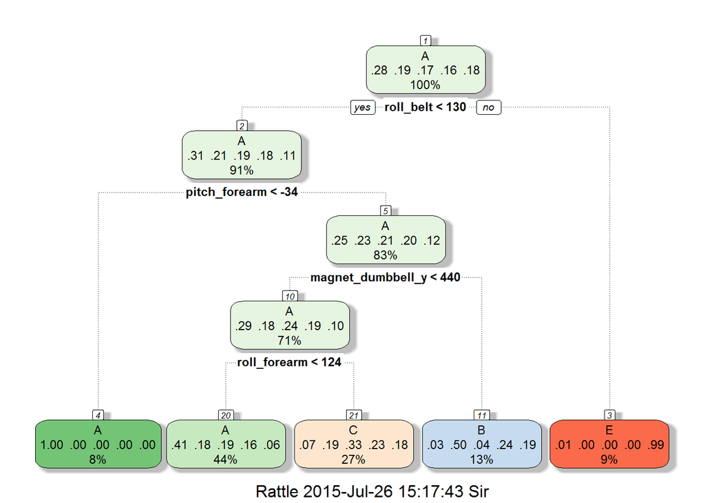

```r
fancyRpartPlot(modelRPART$finalModel)
```

```r
predictRPART <- predict(modelRPART, testSet)
confusionMatrix(testSet$classe, predictRPART)
```

[output not shown]

Regressino tree model provides accuracy of about 50%, which is on par with chance.

#### Random forest model

Let’s use Random Forest model and test whether it can provide better accuracy in predicting outcome classe.

```r
modelRF <- train(classe ~ .,
                 data=trainSet,
                 method="rf",
                 trControl=trainControl(method="cv", number=4))
modelRF
```

```
## Random Forest
##
## 9812 samples
##   52 predictor
##    5 classes: 'A', 'B', 'C', 'D', 'E'
##
## No pre-processing
## Resampling: Cross-Validated (4 fold)
##
## Summary of sample sizes: 7358, 7360, 7360, 7358
##
## Resampling results across tuning parameters:
##
##   mtry  Accuracy   Kappa      Accuracy SD  Kappa SD
##    2    0.9850181  0.9810431  0.002340403  0.002961266
##   27    0.9867503  0.9832382  0.002549619  0.003227082
##   52    0.9815518  0.9766577  0.005698671  0.007214673
##
## Accuracy was used to select the optimal model using  the largest value.
## The final value used for the model was mtry = 27.
```

```r
varImp(modelRF)
```

```
## rf variable importance
##
##   only 20 most important variables shown (out of 52)
##
##                      Overall
## roll_belt            100.000
## pitch_forearm         57.377
## yaw_belt              50.640
## magnet_dumbbell_z     47.389
## magnet_dumbbell_y     42.069
## roll_forearm          38.694
## pitch_belt            38.204
## accel_dumbbell_y      25.588
## accel_forearm_x       19.292
## magnet_dumbbell_x     16.768
## roll_dumbbell         16.016
## magnet_belt_z         14.307
## accel_dumbbell_z      14.099
## total_accel_dumbbell  13.645
## accel_belt_z          13.567
## magnet_forearm_z      13.378
## magnet_belt_y         11.534
## gyros_belt_z          10.901
## yaw_arm                9.985
## magnet_belt_x          9.798
```

```r
predictRF <- predict(modelRF, testSet)
cRF <- confusionMatrix(testSet$classe, predictRF)
```

Random Forest model provides far better accuracy then regression tree.

#### In Sample and Out of Sample Error

In sample error is the rate of error in the set used for training and out of sample error is the rate of error in the set used for testing. Very high accuracy achieved using Random Forest model 0.9872579 means very low out of sample error

```r
1-cRF$overall[[1]]
```

```
## [1] 0.0127421
```

The in sample error will be even smaller. Predicting on the training set should give accuracy of almost or full 100%. Let’s test this hypothesis

```r
predictTrainRF <- predict(modelRF, trainSet)
cTrainRF <- confusionMatrix(trainSet$classe, predictTrainRF)
cTrainRF
```

```
## Confusion Matrix and Statistics
##
##           Reference
## Prediction    A    B    C    D    E
##          A 2790    0    0    0    0
##          B    0 1899    0    0    0
##          C    0    0 1711    0    0
##          D    0    0    0 1608    0
##          E    0    0    0    0 1804
##
## Overall Statistics
##
##                Accuracy : 1
##                  95% CI : (0.9996, 1)
##     No Information Rate : 0.2843
##     P-Value [Acc > NIR] : < 2.2e-16
##
##                   Kappa : 1
##  Mcnemar's Test P-Value : NA
##
## Statistics by Class:
##
##                      Class: A Class: B Class: C Class: D Class: E
## Sensitivity            1.0000   1.0000   1.0000   1.0000   1.0000
## Specificity            1.0000   1.0000   1.0000   1.0000   1.0000
## Pos Pred Value         1.0000   1.0000   1.0000   1.0000   1.0000
## Neg Pred Value         1.0000   1.0000   1.0000   1.0000   1.0000
## Prevalence             0.2843   0.1935   0.1744   0.1639   0.1839
## Detection Rate         0.2843   0.1935   0.1744   0.1639   0.1839
## Detection Prevalence   0.2843   0.1935   0.1744   0.1639   0.1839
## Balanced Accuracy      1.0000   1.0000   1.0000   1.0000   1.0000
```

As expected, in sample accuracy is 1, which makes in sample error rate equal:

```r
1 - cTrainRF$overall[[1]]
```

```
## [1] 0
```